# STWUR #4: czynniki w R, czyli samotność w sieci

## Wstęp

Materiały są dostępne w repozytorium: http://tinyurl.com/stwur4

Pobierz materiały z **R** poleceniem:

```r
download.file(url = "https://github.com/STWUR/STWUR-2017-05-17/archive/master.zip",
              destfile = "tmp.zip")
unzip("tmp.zip", exdir = getwd())
file.remove("tmp.zip")
```

## Dane

Dane z Diagnozy społecznej, 23 130 respondentów.

Pytania:

- Czy czuje się Pan/i samotny/a?
- Czy używa Pan/i internetu w pracy?
- Ile godzin spędził/a Pan/i w internecie w ostatnim tygodniu?

## Wczytanie danych

```r
dat <- read.csv("internet_samotnosc_aggregated.csv")
head(dat)
```

```
##        plec internet_zawodowo samotnosc internet_h n_resp
## 1 mężczyzna               TAK       TAK   18.68534    734
## 2 mężczyzna               TAK       NIE   16.78936   4266
## 3 mężczyzna               NIE       TAK   11.90459    711
## 4 mężczyzna               NIE       NIE   10.89156   4970
## 5   kobieta               TAK       TAK   15.88870   1218
## 6   kobieta               TAK       NIE   13.77824   4369
## ----
##  1 rows ommited
```

## Liczba respondentów

```r
ggplot(dat, aes(x = plec, y = n_resp, fill = samotnosc)) +
  geom_col(position = "dodge") +
  facet_wrap( ~ internet_zawodowo, labeller = label_both) +
  scale_x_discrete("Płeć") +
  scale_y_continuous("Liczba respondentów") +
  scale_fill_manual("Uczucie osamotnienia",
                    values = c("cadetblue3", "coral2")) +
  theme_bw() +
  theme(legend.position = "bottom")
```

## Liczba respondentów

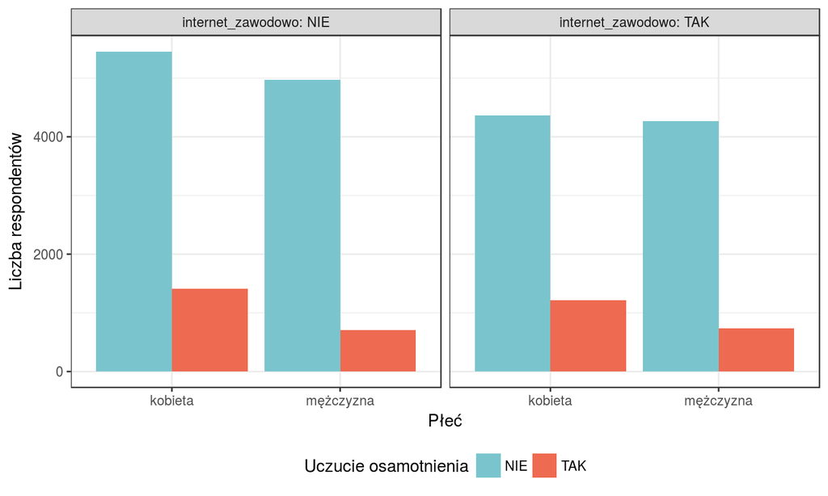

*geom_col*: odpowiednik geom_bar(stat = "identity")

## Przedziały ufności

```r
conf_int <- group_by(dat, internet_zawodowo) %>%
  mutate(total = sum(n_resp)) %>%
  bind_cols(binom.confint(.[["n_resp"]], .[["total"]],
                          method = "asymptotic")) %>%
  select(-method, -x, -n, -mean)
conf_int[1L:3, -c(1L:4)]
```

```
## # A tibble: 3 × 4
##   n_resp total      lower      upper
##    <int> <int>      <dbl>      <dbl>
## 1    734 10587 0.06449170 0.07416892
## 2   4266 10587 0.39360389 0.41229013
## 3    711 12543 0.05263822 0.06073179
## ----
##  -1 rows ommited
```

*binom.confint* - przedziały ufności dla zmiennych dwumianowych (9 dostępnych metod).

*bind_cols* - *cbind* dla tibble.

## Przedziały ufności

```r
ggplot(conf_int, aes(x = plec, y = n_resp, fill = samotnosc)) +
  geom_col(position = "dodge") +
  facet_wrap( ~ internet_zawodowo, labeller = label_both) +
  scale_x_discrete("Płeć") +
  scale_y_continuous("Liczba respondentów") +
  scale_fill_manual("Uczucie osamotnienia",
                    values = c("cadetblue3", "coral2")) +
  theme_bw() +
  theme(legend.position = "bottom") +
  geom_errorbar(aes(ymin = lower*total, ymax = upper*total),
                position = "dodge")
```

## Przedziały ufności

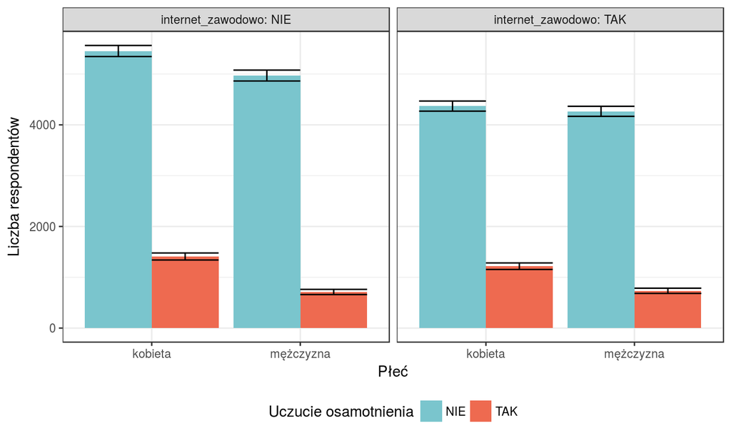

## Przedziały ufności

Coverage probability: prawdopodobieństwo, że wartość zmiennej znajduje się w określonym przedziale ufności.

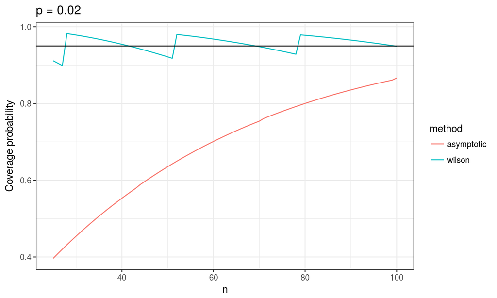

## Przedziały ufności

```
##       method      p     n  coverage
## 1 asymptotic 0.0567 10587 0.9488404
## ----
##  -4 rows ommited
```

```
##   method      p     n  coverage
## 1 wilson 0.0567 10587 0.9493279
## ----
##  -4 rows ommited
```

## Liczba respondentów

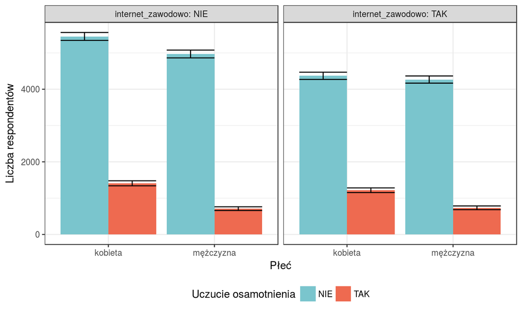

## Liczba godzin w internecie a samotność

```r
ggplot(dat, aes(x = plec, y = internet_h, fill = samotnosc)) +
  geom_col(position = "dodge") +
  facet_wrap( ~ internet_zawodowo, labeller = label_both) +
  scale_x_discrete("Płeć") +
  scale_y_continuous("Użycie internetu w ostatnim tygodniu [h]") +
  scale_fill_manual("Uczucie osamotnienia", values = c("cadetblue3", "coral2")) +
  theme_bw() +
  theme(legend.position = "bottom")
```

## Liczba godzin w internecie a samotność

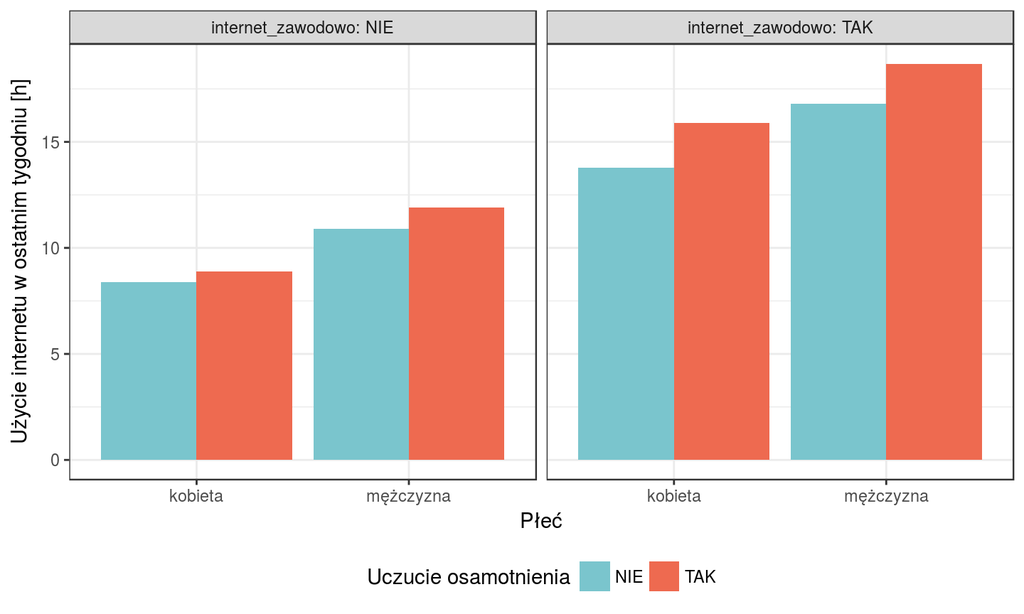

## Liczba godzin w internecie a samotność

```r
full_dat <- read.csv("internet_samotnosc_full.csv")

wilcox.test(filter(full_dat, samotnosc == "TAK")[["internet_h"]],
            filter(full_dat, samotnosc != "TAK")[["internet_h"]],
            alternative = "greater")
```

```
##
##  Wilcoxon rank sum test with continuity correction
##
## data:  filter(full_dat, samotnosc == "TAK")[["internet_h"]] and filter(full_dat, samotnosc != "TAK")[["internet_h"]]
## W = 40072000, p-value = 0.0004915
## alternative hypothesis: true location shift is greater than 0
```

## Liczba godzin w internecie a samotność

Czy osoby samotne nieużywające internetu w pracy, spędzają w internecie więcej czasu niż ich mniej samotni koledzy?

```r
wilcox.test(filter(full_dat, samotnosc == "TAK",
                   internet_zawodowo != "TAK")[["internet_h"]],
            filter(full_dat, samotnosc != "TAK",
                   internet_zawodowo != "TAK")[["internet_h"]],
            alternative = "greater")
```

```
##
##  Wilcoxon rank sum test with continuity correction
##
## data:  filter(full_dat, samotnosc == "TAK", internet_zawodowo != "TAK")[["internet_h"]] and filter(full_dat, samotnosc != "TAK", internet_zawodowo != "TAK")[["internet_h"]]
## W = 11058000, p-value = 0.4745
## alternative hypothesis: true location shift is greater than 0
```

## Liczba godzin w internecie a samotność

Czy osoby samotne używające internetu w pracy, spędzają w internecie więcej czasu niż ich mniej samotni koledzy?

```r
wilcox.test(filter(full_dat, samotnosc == "TAK",
                   internet_zawodowo == "TAK")[["internet_h"]],
            filter(full_dat, samotnosc != "TAK",
                   internet_zawodowo == "TAK")[["internet_h"]],
            alternative = "greater")
```

```
##
##  Wilcoxon rank sum test with continuity correction
##
## data:  filter(full_dat, samotnosc == "TAK", internet_zawodowo == "TAK")[["internet_h"]] and filter(full_dat, samotnosc != "TAK", internet_zawodowo == "TAK")[["internet_h"]]
## W = 8897900, p-value = 5.457e-05
## alternative hypothesis: true location shift is greater than 0
```

## Liczba godzin w internecie a samotność

Czy osoby samotne używające internetu w pracy, spędzają w internecie więcej czasu niż ich mniej samotni koledzy?

```r
wilcox.test(filter(full_dat, samotnosc == "TAK",
                   internet_zawodowo == "TAK")[["internet_h"]],
            filter(full_dat, samotnosc != "TAK",
                   internet_zawodowo == "TAK")[["internet_h"]],
            alternative = "greater")
```

```
##
##  Wilcoxon rank sum test with continuity correction
##
## data:  filter(full_dat, samotnosc == "TAK", internet_zawodowo == "TAK")[["internet_h"]] and filter(full_dat, samotnosc != "TAK", internet_zawodowo == "TAK")[["internet_h"]]
## W = 8897900, p-value = 5.457e-05
## alternative hypothesis: true location shift is greater than 0
```

Czy naprawdę? Nie, na następnym spotkaniu wspólnie zrobimy to jeszcze raz - tym razem prawidłowo uwzględniając wagi!

## Trzy triki na factory

Zmiana kolejnosci poziomów

```r
fct_dat <- data.frame(imie = c("Janek", "Franek", "Stefanek", "Havranek"),
                      wzrost = c(188, 168, 210, 199))

levels(fct_dat[["imie"]])
```

```
## [1] "Franek"   "Havranek" "Janek"    "Stefanek"
```

```r
fct_dat2 <- mutate(fct_dat,
                   imie = factor(imie, levels = imie[order(wzrost)]))
levels(fct_dat2[["imie"]])
```

```
## [1] "Franek"   "Janek"    "Havranek" "Stefanek"
```

## Trzy triki na factory

Zmiana nazw poziomów

```r
fct_dat2 <- mutate(fct_dat,
                   imie = factor(imie, labels = toupper(levels(imie))))
levels(fct_dat2[["imie"]])
```

```
## [1] "FRANEK"   "HAVRANEK" "JANEK"    "STEFANEK"
```

## Trzy triki na factory

Łączenie poziomow

```r
fct_dat2 <- fct_dat
levels(fct_dat2[["imie"]]) <- c("Franek", "Janek", "Janek", "Stefanek")

levels(fct_dat2[["imie"]])
```

```
## [1] "Franek"   "Janek"    "Stefanek"
```

## Dane (raz jeszcze)

- plec: płeć
- waga: ważność obserwacji, istotne przy wyciąganiu średnich
- woj: województwo
- region66: region NUTS3.
- internet_zawodowo: czy używa Pan/i internetu w pracy?
- samotnosc: Czy czuje się Pan/i samotny/a?
- internet_h: Ile godzin spędził/a Pan/i w internecie w ostatnim tygodniu?
- rok: rok sondażu.